# Limpieza y organización de los datos del #MenstruScrapper

Datos de Marzo 2024

[figure not shown]

## Preparando el entorno de trabajo

Comenzamos levantando las librerías necesarias, cargando los datos srappeados desde el archivo .csv, y un diccionario que indica a qué región pertenece cada provincia del país.

```r
library(EnvStats)
library(tidyverse)
library(ggridges)
library(openxlsx)
library(viridis)
library(readxl)
library(magrittr)
library(scales)
library(kableExtra)

datos <- read.csv("Fuentes/precios-gestion-menstrual-2024-03-05.csv",
                  header = TRUE, sep = ",", dec = ".",
                  fill = TRUE, encoding = "UTF-8")

regiones <- openxlsx::read.xlsx("Fuentes/provincias_regiones.xlsx")

total_observaciones <- nrow(datos)

datos <- datos %>% mutate(Categoría = case_when(
  str_detect(Nombre, "Copa") == TRUE ~ "copa",
  TRUE ~ Categoría
))

datos <- datos %>% filter(Categoría != "copa")

total_sin_copas <- nrow(datos)
```

En septiembre de 2022, por primera vez se encontró entre los registros obtenidos algunos con la palabra “copa” dentro de la descripción, que se encontraban camuflados dentro del categoría tampón. Para poder continuar correctamente con el preprocesamiento, creamos la categoría “copa”, para poder distinguir realmente estos productos de las toallitas y los tampones, luego la filtramos por el momento. En total hay 30543 observaciones, de las cuales filtramos 22 correspondientes a la nueva categoría “copa”, arribando así a 30521 observaciones. Sobre esta muestra trabajaremos a lo largo del resto del documento.

## Presentación

En el marco del cálculo del costo de menstruar en Argentina, llevado a cabo desde la campaña #MenstruAcción y EcoFeminita, en el presente documento de trabajo se encuentra la exploración, organización y limpieza de los datos obtenidos mediante el [#MenstruScrapper](https://github.com/lasdesistemas/menstruscrapper), desarrollado por Nayla Portas de [LAS] de sistemas. El #MenstruScrapper fue ejecutado el día 5 de Marzo de 2024 sobre la página Precios Claros, sumándose esta información a la obtenida anteriormente desde Marzo de 2019 semestralmente, todos los marzos y septiembres. En esta instancia, se obtuvieron 30521 observaciones de tampones y toallitas en total.

- Respecto de los tampones: Se obtuvieron 6032 precios.
- Respecto de las toallitas: Se obtuvieron 24489 precios.

En [nuestro repositorio](https://github.com/Ecofeminita/EcoFemiData/tree/master/MenstruAccion/cuanto_cuesta_menstruar) se encuentran aclaradas todas las fuentes adicionales a las que se recurrió para realizar el cálculo y los archivos correspondientes. En otro paso se encuentra el cálculo propiamente dicho del costo anual de menstruar.

Vista previa del dataset:

```r
head(datos)
```

|  | Categoría | Marca | Nombre | Presentación | Comercio | Sucursal | Dirección | Localidad | Provincia | Precio.de.lista |
| --- | --- | --- | --- | --- | --- | --- | --- | --- | --- | --- |
| 1 | tampones | CARREFOUR | Tampones Medio Carrefour 8 Un | 8.0 un | INC S.A. | Salta | 20 De Febrero 37 | Salta | Salta | 1999 |
| 2 | tampones | CARREFOUR | Tampones Medio Carrefour 8 Un | 8.0 un | INC S.A. | Salta III | Av. Bicentenario Batalla De Salta 702 | Salta | Salta | 1999 |
| 3 | tampones | CARREFOUR | Tampones Medio Carrefour 8 Un | 8.0 un | INC S.A. | Salta VII | Av. Entre Ríos 1816 | Salta | Salta | 1999 |
| 4 | tampones | CARREFOUR | Tampones Medio Carrefour 8 Un | 8.0 un | INC S.A. | Av. Urquiza 4855 | Av. Urquiza 4855 | 3 de Febrero | Buenos Aires | 1999 |
| 5 | tampones | CARREFOUR | Tampones Medio Carrefour 8 Un | 8.0 un | INC S.A. | Acassuso | Av. Del Libertador 14893 | Acassuso | Buenos Aires | 1999 |
| 6 | tampones | CARREFOUR | Tampones Medio Carrefour 8 Un | 8.0 un | INC S.A. | Rosario 4558 | Rosario 4558 | Adolfo Sordeaux | Buenos Aires | 1999 |

Vista previa del diccionario de regiones:

```r
head(regiones)
```

|  | Provincia | Region |
| --- | --- | --- |
| 1 | Buenos Aires | GBA |
| 2 | CABA | GBA |
| 3 | Mendoza | CUY |
| 4 | Córdoba | PAM |
| 5 | Río Negro | PAT |
| 6 | Neuquén | PAT |

Definimos una pequeña función: `cant` nos va a devolver un número en formato character (texto), con cero dígitos, con un punto para separar los miles, y una coma para separar los decimales.

```r
cant <- function(x){
  format(x, digits = NULL, big.mark = ".", decimal.mark = ",")}
```

Guardamos el valor de la fecha a la que corresponde el ejercicio.

```r
date <- "Marzo 2024"
```

## Exploración de los datos

Al dataframe `datos` le pegamos los valores de las regiones, usando como variable de identificación a la `Provincia`. A continuación podemos borrar de nuestro entorno de trabajo el elemento `regiones`.

```r
datos <- left_join(datos, regiones, by = "Provincia")
rm(regiones)
```

```r
names(datos)
```

```
 [1] "Categoría"       "Marca"           "Nombre"          "Presentación"    "Comercio"
 [6] "Sucursal"        "Dirección"       "Localidad"       "Provincia"       "Precio.de.lista"
[11] "Region"
```

```r
cant(nrow(datos))
```

```
[1] "30.521"
```

A continuación, exploraremos el comportamiento de las diferentes variables. Con `count()` pedimos un conteo de observaciones para cada valor que toma la variable aclarada, con `arrange()` ordenamos los datos de forma decreciente según el conteo anterior, y en `mutate()` se definen nuevas variables para nuestro cuadro. Por ejemplo, el porcentaje es la cantidad de cada categoría sobre la suma de las mismas, expresada en formato de porcentaje.

### Categorías

```r
categ
```

| Categoría | n | porcentaje |
| --- | --- | --- |
| toallitas | 24489 | 80% |
| tampones | 6032 | 20% |

Cabe destacar que esta composición corresponde a la disponibilidad de precios, no refleja la estructura del consumo. O sea, no podemos decir que se consumen en un 80% toallitas y en 20% tampones. Lo que sí sabemos es que la página de Precios Claros puede tener un sesgo por no incluir los comercios tradicionales sino únicamente grandes cadenas.

### Marcas

```r
marcas <- datos %>%
  count(Marca) %>%
  arrange(-n) %>%
  mutate(porcentaje = n/sum(n),
         acumulado = cumsum(porcentaje),
         porcentaje = percent(porcentaje),
         acumulado = percent(acumulado)
         )

marcas
```

| Marca | n | porcentaje | acumulado |
| --- | --- | --- | --- |
| SIEMPRE LIBRE | 8693 | 28.4820% | 28.4820% |
| ALWAYS | 4287 | 14.0461% | 42.5281% |
| KOTEX | 3649 | 11.9557% | 54.4838% |
| O.B. | 3234 | 10.5960% | 65.0798% |
| CARREFOUR | 2970 | 9.7310% | 74.8108% |
| NOSOTRAS | 2131 | 6.9821% | 81.7929% |
| DONCELLA | 1358 | 4.4494% | 86.2423% |
| PLENITUD | 1128 | 3.6958% | 89.9381% |
| LADYSOFT | 701 | 2.2968% | 92.2349% |
| PLENITUD FEMME | 641 | 2.1002% | 94.3350% |

[output cut: 10 more lines]

Contamos con 20 marcas de productos, aunque con 8 de ellas se completa casi el 90% del total de productos. Las primeras 3 marcas concentran más de la mitad de las observaciones. Nuevamente aquí hay que tener en cuenta que no se trata exactamente de una “concentración de mercado”.

### Presentación

```r
datos %>%
  count(Presentación) %>%
  arrange(-n) %>%
  mutate(porcentaje = n/sum(n),
         acumulado = cumsum(porcentaje),
         porcentaje = percent(porcentaje),
         acumulado = percent(acumulado))
```

| Presentación | n | porcentaje | acumulado |
| --- | --- | --- | --- |
| 8.0 un | 16312 | 53.445% | 53.4452% |
| 16.0 un | 10176 | 33.341% | 86.7861% |
| 32.0 un | 1094 | 3.584% | 90.3706% |
| 20.0 un | 863 | 2.828% | 93.1981% |
| 14.0 un | 818 | 2.680% | 95.8782% |
| 12.0 un | 475 | 1.556% | 97.4346% |
| 10.0 un | 436 | 1.429% | 98.8631% |
| 30.0 un | 216 | 0.708% | 99.5708% |
| 24.0 un | 122 | 0.400% | 99.9705% |
| 7.0 un | 7 | 0.023% | 99.9934% |

[output cut: 2 more lines]

Más del 80% de los productos vienen en paquetes de 8 o 16 unidades. Luego seguiremos analizando esta variable en particular, porque nos interesa para calcular los precios unitarios de los productos, y hay valores (como “1.0 un”) que son raros y, en caso de tratarse de errores, podrían arrastrar problemas hacia el cálculo de esos precios.

### Provincias

```r
prov <- datos %>%
  count(Provincia) %>%
  arrange(-n) %>%
  mutate(porcentaje = n/sum(n),
         acumulado = cumsum(porcentaje),
         porcentaje = percent(porcentaje),
         acumulado = percent(acumulado))

prov
```

| Provincia | n | porcentaje | acumulado |
| --- | --- | --- | --- |
| Buenos Aires | 9877 | 32.3613% | 32.36% |
| CABA | 9062 | 29.6910% | 62.05% |
| Córdoba | 2262 | 7.4113% | 69.46% |
| Mendoza | 1423 | 4.6624% | 74.13% |
| Santa Fe | 962 | 3.1519% | 77.28% |
| Tucumán | 812 | 2.6605% | 79.94% |
| Entre Ríos | 770 | 2.5229% | 82.46% |
| Chubut | 660 | 2.1624% | 84.62% |
| Misiones | 615 | 2.0150% | 86.64% |
| Salta | 585 | 1.9167% | 88.56% |

[output cut: 14 more lines]

Si bien el 62.05% de las observaciones se concentran en Buenos Aires y CABA, es importante saber que se cuenta con información de todas las provincias del país, y que incluso en el peor de los casos (por ejemplo, 126 observaciones en La Rioja) se trata de una cantidad pasible de proveernos estimaciones útiles.

### Regiones

```r
r <- datos %>%
  count(Region) %>%
  arrange(-n) %>%
  mutate(porcentaje = n/sum(n),
         acumulado = cumsum(porcentaje),
         porcentaje = percent(porcentaje),
         acumulado = percent(acumulado))

r
```

| Region | n | porcentaje | acumulado |
| --- | --- | --- | --- |
| GBA | 18939 | 62.05% | 62.1% |
| PAM | 4253 | 13.93% | 76.0% |
| NOA | 2206 | 7.23% | 83.2% |
| CUY | 2078 | 6.81% | 90.0% |
| PAT | 1652 | 5.41% | 95.4% |
| NEA | 1393 | 4.56% | 100.0% |

En términos regionales seguimos viendo esa asimetría en la disponibilidad de datos, pero hay que tener en cuenta que efectivamente hay diferencias de escala de mercados en términos regionales.

### Precio de lista

Ahora graficamos la distribución de los precios de lista (o sea, sin tener en cuenta las unidades por paquete) según cada categoría. Para ello utilizamos `ggplot2`.

En la primer línea de código referida a `ggplot`, tomamos como fuente el dataset que venimos utilizando (a eso refiere el punto), en el `eje x` queremos los precios, en el `eje y` queremos cada categoría, y el relleno de cada parte del gráfico también según las categorías de productos. En la segunda línea aclaramos que queremos un gráfico de densidad (que es como un histograma pero en versión continua), la escala hace a la superposición de los graficos y el `bandwidth` o “ancho de banda” indica la extensión del intervalo de valores con los que se va a realizar la estimación del gráfico (o sea, si el gráfico va a ser más detallista y por ende más “ruidoso”, o más suave y “redondeado”). Se puede jugar con ambos valores para ver sus efectos. En la tercer línea aclaramos que queremos un tema minimalista, en la cuarta que la paleta de colores la vamos a asignar de manera manual, en la quinta que no queremos una leyenda aclarando los colores de cada categoría porque ya están aclaradas en el eje y. Y por último aclaramos las etiquetas necesarias.

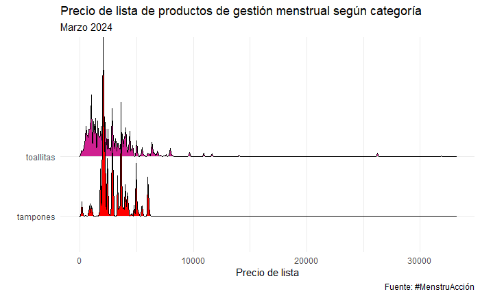

```r
datos %>%
  ggplot(., aes(x = Precio.de.lista, y = Categoría, fill = Categoría)) +
  geom_density_ridges(scale = 3, bandwidth = 20) +
  theme_minimal() +
  scale_fill_manual(values = c("red", "violetred")) +
  theme(legend.position = "none") +
  labs(title = "Precio de lista de productos de gestión menstrual según categoría",
       subtitle = date,
       x = "Precio de lista",
       y = "",
       caption = "Fuente: #MenstruAcción")
```

Por esta vez, filtramos de los datos los precios mayores a 3.000 pesos, basicamente porque hay casos (outliers que de hecho vamos a tener que corregir) que superan ese monto y “rompen” la escala del gráfico. Para una comprensión más acabada de este efecto, veamos qué sucede si quitamos estos valores que hasta superan los 3.000 pesos:

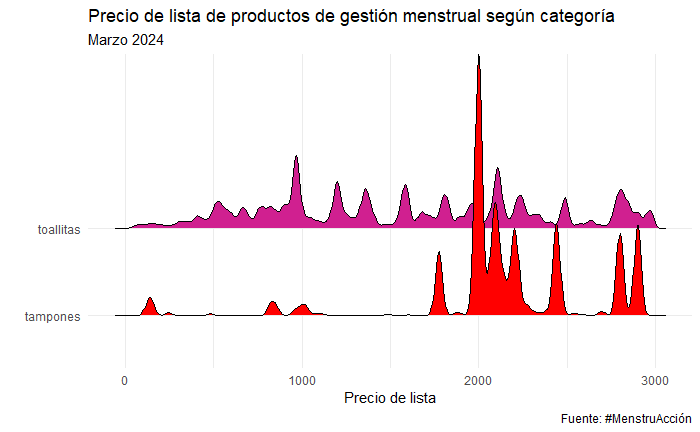

```r
# Solo en esta ocasión por los outliers presentes:

datos <- datos %>%
  filter(Precio.de.lista < 3000) #saco los outliers mayores a 1000 porque son demasiado altos.
# El resto va a ser controlado a la hora de calcular la media de precios de forma "podada"

datos %>%
  ggplot(., aes(x = Precio.de.lista, y = Categoría, fill = Categoría)) +
  geom_density_ridges(scale = 3, bandwidth = 20) +
  theme_minimal() +
  scale_fill_manual(values = c("red", "violetred")) +
  theme(legend.position = "none") +
  labs(title = "Precio de lista de productos de gestión menstrual según categoría",
       subtitle = date,
       x = "Precio de lista",
       y = "",
       caption = "Fuente: #MenstruAcción")
```

También podemos graficar los precios de cada categoría por regiones:

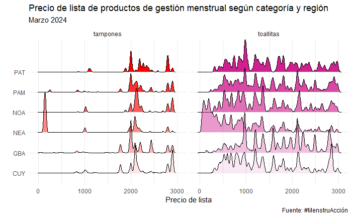

```r
datos %>%
  ggplot(., aes(x = Precio.de.lista, y = Region, fill = Categoría, alpha = Region)) +
  geom_density_ridges(scale = 2, bandwidth = 20) + # el bandwidth anterior estaba en 10
  theme_minimal() +
  scale_fill_manual(values = c("red", "violetred"))+
  facet_wrap(. ~ Categoría) +
  theme(legend.position = "none") +
  labs(title = "Precio de lista de productos de gestión menstrual según categoría y región",
       subtitle = date,
       x = "Precio de lista",
       y = "",
       caption = "Fuente: #MenstruAcción")
```

## Limpieza de la cantidad de unidades (Presentación)

Como mencionábamos anteriormente, es necesario prestarle particular atención a la variable de `Presentación`, que indica la cantidad de unidades por cada paquete. En primer lugar, teniendo en cuenta que está expresada como “X un.”, modificamos la variable para quedarnos únicamente con las unidades en formato numérico. Esto lo hacemos convirtiendo la variable al tipo character, y luego quedándonos con aquellos caracteres entre la primer posición y aquella que se encuentra 4 posiciones por detrás de la última (omitiendo así “.0 un”). En la tabla `presentacion_nros` resumimos el comportamiento de esta nueva variable `unidades`.

```r
datos <- datos %>%
  mutate(Presentación = as.character(Presentación),
         unidades = as.numeric(substr(Presentación, 1, nchar(Presentación)-4)))

presentacion_nros <- datos %>%
  count(unidades) %>%
  arrange(-n) %>%
  mutate(porcentaje = n/sum(n),
         acumulado = cumsum(porcentaje),
         porcentaje = percent(porcentaje),
         acumulado = percent(acumulado))

presentacion_nros
```

| unidades | n | porcentaje | acumulado |
| --- | --- | --- | --- |
| 8 | 13318 | 68.001% | 68.0010% |
| 16 | 5119 | 26.137% | 94.1384% |
| 14 | 656 | 3.350% | 97.4879% |
| 10 | 316 | 1.613% | 99.1014% |
| 24 | 122 | 0.623% | 99.7243% |
| 32 | 27 | 0.138% | 99.8621% |
| 30 | 10 | 0.051% | 99.9132% |
| 7 | 7 | 0.036% | 99.9489% |
| 20 | 7 | 0.036% | 99.9847% |
| 1 | 1 | 0.005% | 99.9898% |

[output cut: 2 more lines]

Sin embargo, en la base puede verse que hay casos que, de acuerdo a la descripción en `Nombre`, tienen mal la cantidad de unidades en `Presentacion` (y por ende en unidades), afectando el calculo de precios unitarios.  
Utilizando expresiones regulares podemos quedarnos con los dígitos, sean uno o más, que están seguidos de “Un” o “un” en la variable `Nombre`. Nos quedamos con esta información en la variable `unidades_regex` y resumimos su comportamiento.

```r
datos <- datos %>%
  mutate(unidades_regex = as.numeric(str_extract(Nombre, '\\d+(?=\\s*[Uu]n?)')))

presentacion_regex <- datos %>%
  count(unidades_regex) %>%
  arrange(-n) %>%
  mutate(porcentaje = n/sum(n),
         acumulado = cumsum(porcentaje),
         porcentaje = percent(porcentaje),
         acumulado = percent(acumulado))
presentacion_regex
```

| unidades_regex | n | porcentaje | acumulado |
| --- | --- | --- | --- |
| 8 | 13288 | 67.848% | 67.8478% |
| 16 | 5120 | 26.142% | 93.9903% |
| 14 | 656 | 3.350% | 97.3398% |
| 10 | 316 | 1.613% | 98.9533% |
| 24 | 122 | 0.623% | 99.5762% |
| NA | 31 | 0.158% | 99.7345% |
| 32 | 27 | 0.138% | 99.8724% |
| 30 | 10 | 0.051% | 99.9234% |
| 7 | 7 | 0.036% | 99.9592% |
| 20 | 7 | 0.036% | 99.9949% |

[output cut: 1 more lines]

```r
datos <- datos %>%
  mutate(igual = case_when(unidades == unidades_regex ~ T,
                           unidades != unidades_regex ~ F))

comparo_unidades <- datos %>%
  count(unidades, unidades_regex) %>%
  mutate(igual = case_when(unidades == unidades_regex ~ T,
                           unidades != unidades_regex ~ F)) %>%
  arrange(igual, -n)

comparo_unidades
```

| unidades | unidades_regex | n | igual |
| --- | --- | --- | --- |
| 27 | 16 | 1 | FALSE |
| 8 | 8 | 13288 | TRUE |
| 16 | 16 | 5119 | TRUE |
| 14 | 14 | 656 | TRUE |
| 10 | 10 | 316 | TRUE |
| 24 | 24 | 122 | TRUE |
| 32 | 32 | 27 | TRUE |
| 30 | 30 | 10 | TRUE |
| 7 | 7 | 7 | TRUE |
| 20 | 20 | 7 | TRUE |

[output cut: 3 more lines]

```r
comparo_unidades %>% filter(igual == FALSE) %>% summarise(n=sum(n))
```

| n |
| --- |
| 1 |

```r
cants_iguales <- datos %>%
  group_by(igual) %>%
  summarise(n = n()) %>%
  mutate(porc = percent(n/sum(n)))

cants_iguales
```

| igual | n | porc |
| --- | --- | --- |
| FALSE | 1 | 0.01% |
| TRUE | 19553 | 99.84% |
| NA | 31 | 0.16% |

Como puede verse arriba, hay en total 1 casos en que la información no coincide, lo que representa el 0.01% de la información, y sólo 31 casos en que no había información sobre la cantidad de unidades en la descripción del artículo.

```r
# Distribucion de los datos que queremos sacar entre las regiones
datos %>%
  filter(igual == FALSE) %>%
  count(Region)
```

| Region | n |
| --- | --- |
| PAM | 1 |

```r
# Distribucion de los datos que queremos sacar entre las marcas
datos %>%
  filter(igual == FALSE) %>%
  count(Marca)
```

| Marca | n |
| --- | --- |
| LADYSOFT | 1 |

### Aclaración

En un ejercicio anterior (septiembre 2019), prescindimos de los valores faltantes en `unidades_regex` (por más que tengan valor en `unidades`, aquella que surge de la variable `Presentación`). Verificamos aquellos casos en que `unidades_regex` (que surge del texto en `Nombre`) no coincide con la variable `unidades`, y establecimos que las cantidades referidas a las unidades por paquete parecen ser mejor captadas con el método de regex sobre el texto del `Nombre` del producto, respecto de lo surgido de la información de la página como `Presentación`. Nos quedamos con `unidades_regex` para calcular el precio por unidad de los productos.

```r
datos <- datos %>%
  filter(igual == TRUE)
```

Luego de esta limpieza, ahora contamos con 19.553 observaciones. También podemos deshacernos de variables que no vamos a utilizar en el ejercicio de estimación.

```r
# Descarto las variables que no voy a usar
datos <- datos %>%
  select(-Presentación, -unidades_regex, -igual)
```

## Cálculo del precio por unidad

Creo la variable `precio_unidad`, dividiendo el `Precio.de.lista` por las `unidades`.

```r
datos <- datos %>%
  mutate(precio_unidad = round(Precio.de.lista/unidades, 2))
```

## Gráficos del precio por unidad

Ahora podemos observar la distribución de esta nueva variable con los mismos gráficos que utilizamos antes.

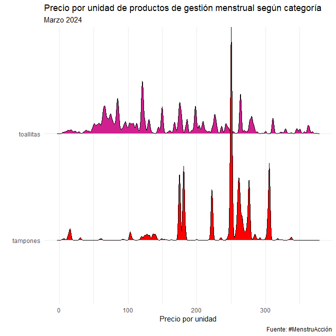

```r
ggplot(datos, aes(x = precio_unidad, y = Categoría, fill = Categoría)) +
  geom_density_ridges(scale = 2, bandwidth = 1.25) + # el bandwidth anterior estaba en 10
  theme_minimal() +
  scale_fill_manual(values = c("red", "violetred")) +
  theme(legend.position = "none") +
  labs(title = "Precio por unidad de productos de gestión menstrual según categoría",
       subtitle = date,
       x = "Precio por unidad",
       y = "",
       caption = "Fuente: #MenstruAcción")
```

Esta vez, para realizar el gráfico por categorías y regiones, podemos ordenar a estas últimas según su precio promedio en el gráfico. Para ello construimos un vector que las aloje en orden, llamado `reg_ordenadas`. Luego, pisamos la variable `Region` en los datos para que sea de tipo factor, y el orden de la misma esté determinado según el vector previamente definido.

```r
reg_ordenadas <- datos %>%
  group_by(Region) %>%
  summarise(promedio = mean(precio_unidad)) %>%
  arrange(promedio) %$% Region

datos <- datos %>%
  mutate(Region = factor(Region, levels = reg_ordenadas))
```

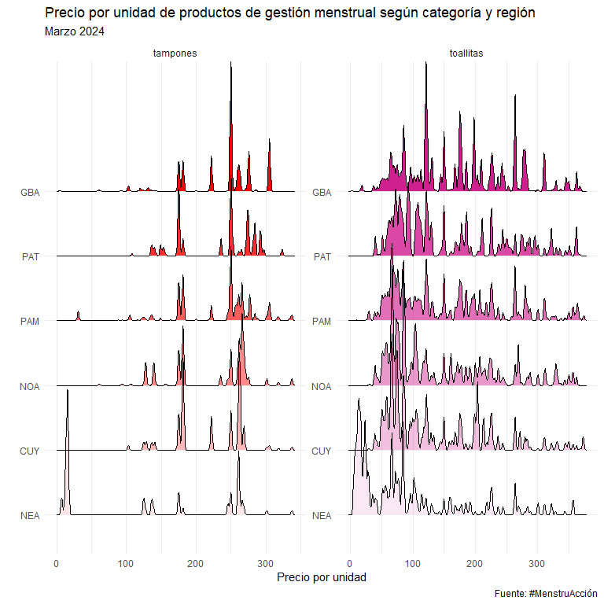

```r
ggplot(datos, aes(x = precio_unidad, y = Region, fill = Categoría, alpha = Region)) +
  geom_density_ridges(scale = 2, bandwidth = 1.25) + # el bandwidth anterior estaba en 1
  theme_minimal() +
  scale_fill_manual(values = c("red", "violetred"))+
  facet_wrap(. ~ Categoría, scales = 'free') +
  theme(legend.position = "none") +
  labs(title = "Precio por unidad de productos de gestión menstrual según categoría y región",
       subtitle = date,
       x = "Precio por unidad",
       y = "",
       caption = "Fuente: #MenstruAcción")
```

## 2,5 % de los extremos de la distribución

Adicionalmente, como el cálculo lo realizaremos agregando los precios de acuerdo a una media alpha podada con alpha = 2,5% (o sea, ignorando los valores superiores e inferiores para evitar la intrusión de outliers a pesar de la limpieza), presentamos gráficos que justamente muestran las “colas” de la distribución que se estarían obviando.

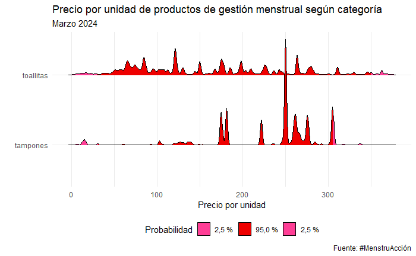

```r
ggplot(datos, aes(x = precio_unidad, y = Categoría, fill = factor(..quantile..))) +
  stat_density_ridges(geom = "density_ridges_gradient",
                      calc_ecdf = TRUE, quantiles = c(0.025, 0.975),
                      bandwidth = 1.25, scale = 1.5) + # El bandwidth anterior estaba en 0.75
  scale_fill_manual(name = "Probabilidad",
                    values = c("violetred1", "red2", "violetred1"),
                    labels = c("2,5 %", "95,0 %", "2,5 %")) +
  theme_minimal() +
  theme(legend.position = "bottom") +
  labs(title = "Precio por unidad de productos de gestión menstrual según categoría",
       subtitle = paste(date),
       x = "Precio por unidad",
       y = "",
       caption = "Fuente: #MenstruAcción")
```

Realizamos el mismo gráfico por cada provincia, ya que esa será la primer unidad de agregación para el cálculo total a nivel nacional.

```r
prov_ordenadas <- datos %>%
  group_by(Provincia) %>%
  summarise(promedio = mean(precio_unidad)) %>%
  arrange(promedio) %$%
  Provincia

datos <- datos %>%
  mutate(Provincia = factor(Provincia, levels = prov_ordenadas))
```

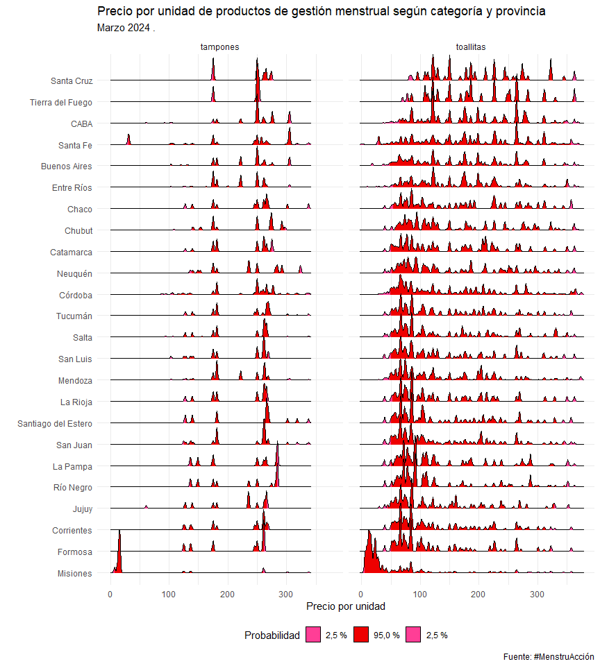

```r
ggplot(datos, aes(x = precio_unidad, y = Provincia,
                  fill = factor(..quantile..))) +
  stat_density_ridges(geom = "density_ridges_gradient",
                      calc_ecdf = TRUE, quantiles = c(0.025, 0.975),
                      bandwidth = 1.25, scale = 2) +
  scale_fill_manual(name = "Probabilidad",
                    values = c("violetred1", "red2", "violetred1"),
                    labels = c("2,5 %", "95,0 %", "2,5 %")) +
  #scale_x_continuous(limits = c(0, 30)) + # El limite anterior estaba en 20
  facet_wrap(. ~ Categoría) +
  theme_minimal() +
  theme(legend.position = "bottom") +
  labs(title = "Precio por unidad de productos de gestión menstrual según categoría y provincia",
       subtitle = paste(date, ". "),
       x = "Precio por unidad",
       y = "",
       caption = "Fuente: #MenstruAcción")
```

Finalmente, guardamos esta nueva versión del dataset en formato .RDS para continuar en el siguiente script con el cálculo de cuánto cuesta menstruar.

```r
saveRDS(datos, file = "Fuentes/precios-gestion-menstrual-2024-03-05-limpio.RDS")
```